# 504 Practical Assignment

Roll No: 17010724108

Md. Thouhidul Islam

October 26, 2022

## Formatting start

```r
code will display like this box
```

```
## [1] "result will be like this box, with ## sign"
```

Text will be like this line

# Problem No-01

### Loading the Data

```r
data("AirPassengers")
AirPassengers
```

```
##      Jan Feb Mar Apr May Jun Jul Aug Sep Oct Nov Dec
## 1949 112 118 132 129 121 135 148 148 136 119 104 118
## 1950 115 126 141 135 125 149 170 170 158 133 114 140
## 1951 145 150 178 163 172 178 199 199 184 162 146 166
## 1952 171 180 193 181 183 218 230 242 209 191 172 194
## 1953 196 196 236 235 229 243 264 272 237 211 180 201
## 1954 204 188 235 227 234 264 302 293 259 229 203 229
## 1955 242 233 267 269 270 315 364 347 312 274 237 278
## 1956 284 277 317 313 318 374 413 405 355 306 271 306
## 1957 315 301 356 348 355 422 465 467 404 347 305 336
## 1958 340 318 362 348 363 435 491 505 404 359 310 337
## 1959 360 342 406 396 420 472 548 559 463 407 362 405
## 1960 417 391 419 461 472 535 622 606 508 461 390 432
```

We can upload file using `read.csv()` function if needed.

## Summarizing and Plotting the data

```r
summary(AirPassengers)
```

```
##    Min. 1st Qu.  Median    Mean 3rd Qu.    Max.
##   104.0   180.0   265.5   280.3   360.5   622.0
```

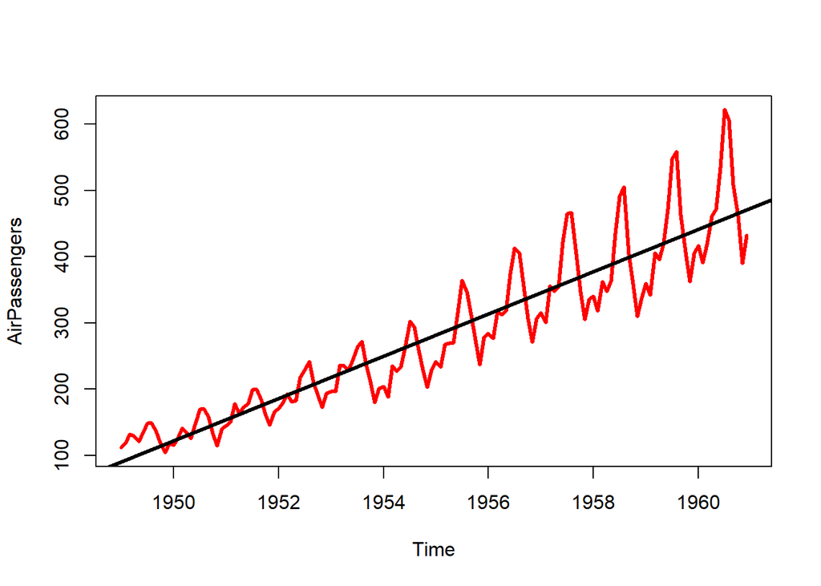

```r
plot(AirPassengers,col="red",lwd=3)
abline(lm(AirPassengers~time(AirPassengers)),lwd=3)
```

This is a basic line plot from where we can see there is **upward trend** and **seasonality** on the data, we can confirm that and decompose that in next plot. Black line is the **regression line**.

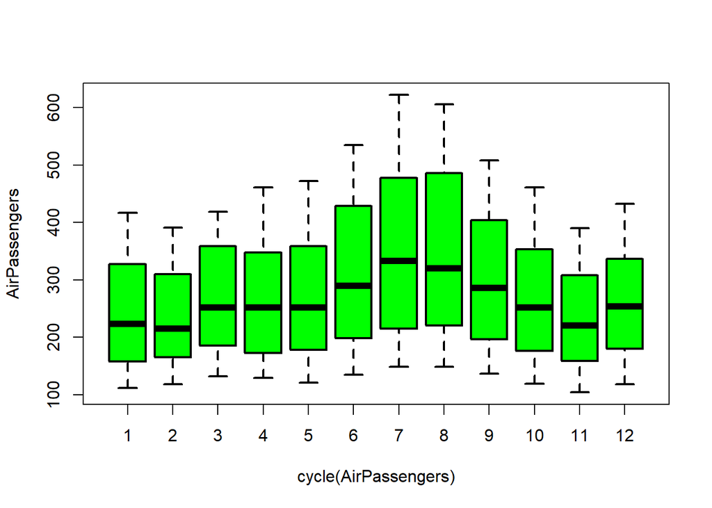

```r
boxplot(AirPassengers~cycle(AirPassengers),col="green",lwd=2)
```

From the **boxplot** we are seeing, Comparatively **high volume of passengers in July and August** than other months each year.

## Time series decomposition into trend, seasonal and random (noise).

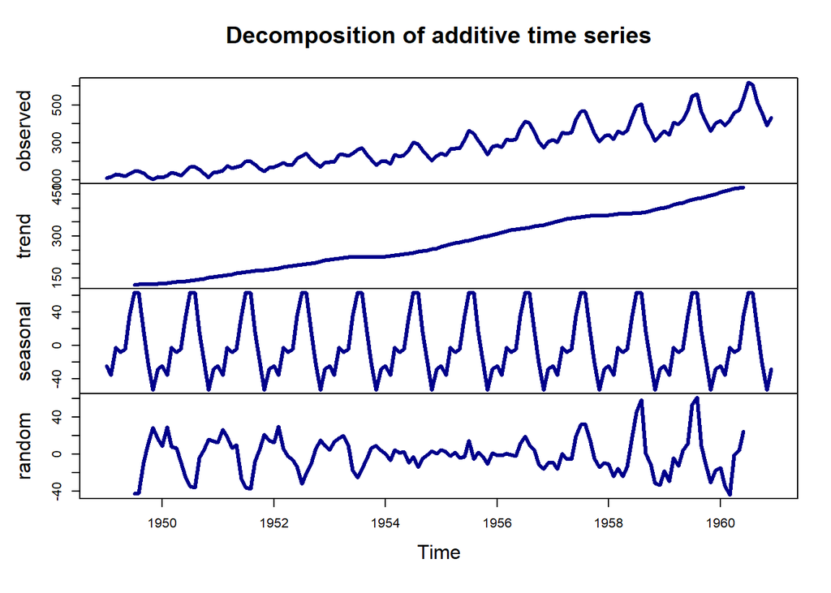

```r
b=decompose(AirPassengers)
plot(b,lwd=3,col="darkblue")
```

When we `decompose` the data, we get *trend, seaonality and random* component from the data. Here we can confirmed that the data has *seasonality* and *upward trend*.

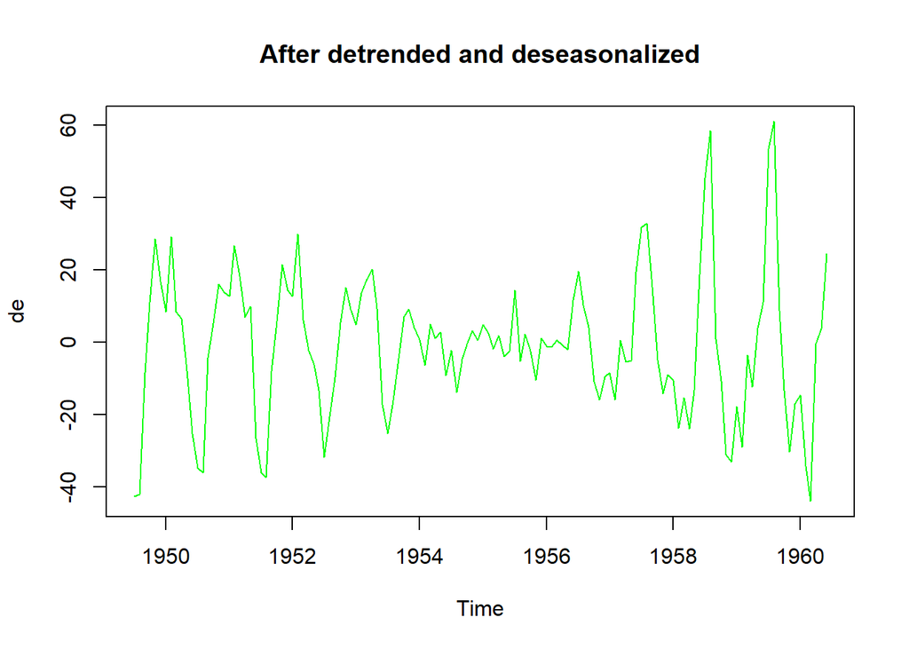

```r
de=na.omit(b$random) #na.omit for deleting missing value
plot(de,col="green",main="After detrended and deseasonalized")
```

We could **de trended and deseaonalized** the original data by keeping only **random component**. Now we will check whether *de trended and deseaonalized* is **stationary** or not.

#### Stationary checking(de trended and deseaonalized data)

```r
library(tseries) # for stationary checking
adf.test(de,k=12) #k= how many lags will we consider
```

```
##
##  Augmented Dickey-Fuller Test
##
## data:  de
## Dickey-Fuller = -4.5382, Lag order = 12, p-value = 0.01
## alternative hypothesis: stationary
```

From adf test we can say that **de trended and deseaonalized** is **stationary** as p<0.05 and out *alnernative hypothesis* is Stationary.

## Stationary checking for original data

```r
adf.test(AirPassengers, k=12)
```

```
##
##  Augmented Dickey-Fuller Test
##
## data:  AirPassengers
## Dickey-Fuller = -1.5094, Lag order = 12, p-value = 0.7807
## alternative hypothesis: stationary
```

```r
pp.test(AirPassengers,lshort = T)
```

```
##
##  Phillips-Perron Unit Root Test
##
## data:  AirPassengers
## Dickey-Fuller Z(alpha) = -46.406, Truncation lag parameter = 4, p-value
## = 0.01
## alternative hypothesis: stationary
```

### Transform the data to stabilize the variance

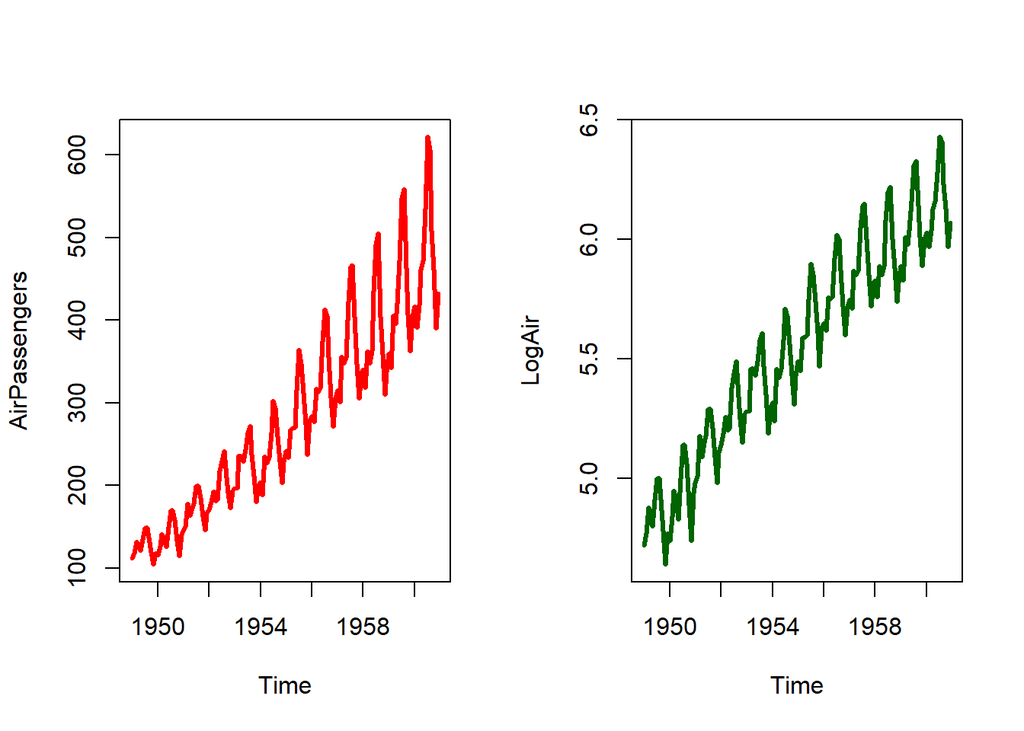

```r
par(mfrow=c(1,2))
LogAir <- round(log(AirPassengers),2)
plot(AirPassengers,col="red",lwd=3)
plot(LogAir,lwd=3, col="darkgreen")
```

Transformation stabilized the variance compared to orginial.

### Difference and Transformation

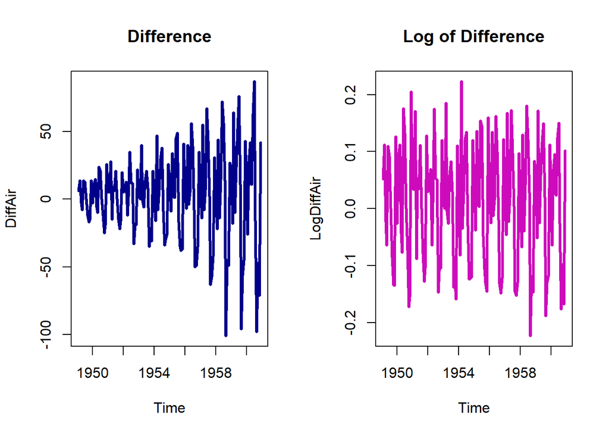

```r
DiffAir<- diff(AirPassengers) #difference of main data
LogDiffAir <- diff(log(AirPassengers)) # log and difference of main data
par(mfrow=c(1,2))
plot(DiffAir,col="darkblue",lwd=3,main="Difference")
plot(LogDiffAir,col=6,lwd=3,main="Log of Difference")
```

From the plot we can now say that, Mean and Variance are approxiamtely constant So, Data is now may be Stationary . We will furthe check.

### Stationary checking for Log Difference data

```r
adf.test(LogDiffAir, k=12)
```

```
##
##  Augmented Dickey-Fuller Test
##
## data:  LogDiffAir
## Dickey-Fuller = -3.3656, Lag order = 12, p-value = 0.06313
## alternative hypothesis: stationary
```

```r
pp.test(LogDiffAir,lshort = T)
```

```
##
##  Phillips-Perron Unit Root Test
##
## data:  LogDiffAir
## Dickey-Fuller Z(alpha) = -93.215, Truncation lag parameter = 4, p-value
## = 0.01
## alternative hypothesis: stationary
```

From Adf test we are seeing data is **stationary at 7% level of signicance.**

From PP test we can say that data is **stationary at 5% level of signicance.**

### Model Selection using ACF and PACF function [ARIMA(p,d,q)(P,D,Q)m]

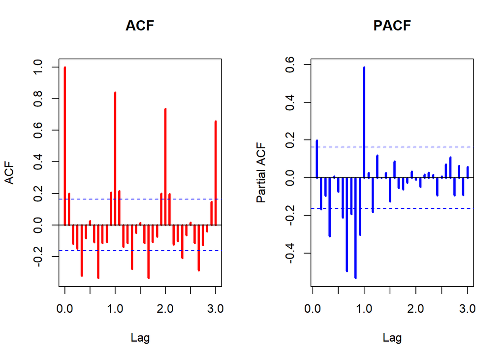

```r
par(mfrow=c(1,2))
acf(diff(log(AirPassengers)),col="red",lwd=3,main="ACF",lag.max = 36)
pacf(diff(log(AirPassengers)),col="blue",lwd=3,main="PACF",lag.max = 36)
```

As, we differentiate the data 1 time to make stationary so d=1

Determine the value **q (Order of MA)** from **ACF plot**. Ignore lag=0, we get q=1. Ignore lag=1, we get Q=1

```r
library(lmtest) #for autocorrelation
original = lm(AirPassengers~time(AirPassengers))
dwtest(original)
```

```
##
##  Durbin-Watson test
##
## data:  original
## DW = 0.53719, p-value < 2.2e-16
## alternative hypothesis: true autocorrelation is greater than 0
```

Original data have high **high positive autocorelation** as DW1<2.

```r
transformed = lm(LogDiffAir~time(LogDiffAir))
dwtest(transformed)
```

```
##
##  Durbin-Watson test
##
## data:  transformed
## DW = 1.5959, p-value = 0.005883
## alternative hypothesis: true autocorrelation is greater than 0
```

Transformed data have comparatively lower **positive autocorelation** than original data as DW2 tends to 2.

### Appropriate Model Selection and Parameter Estimation

```r
model1 = arima(log(AirPassengers),c(0,1,1))
model2 = arima(log(AirPassengers),c(1,1,2))
model3 = arima(log(AirPassengers),c(2,1,2))

model4 = arima(log(AirPassengers),c(0,1,1),
                seasonal = list(order=c(0,1,1),period=12))
model5 = arima(log(AirPassengers),c(0,1,2),
                seasonal = list(order=c(0,1,2),period=12))
model6 = arima(log(AirPassengers),c(1,1,2),seasonal = list(order=c(1,1,2),period=12))

model = c("model1","model2","model3","model4","model5","model6")
AIC = round(c(model1$aic,model2$aic,model3$aic,model4$aic,model5$aic,model6$aic),2)
LL = c(model1$loglik,model2$loglik,model3$loglik,model4$loglik,model5$loglik,model6$loglik)

cbind(model,AIC, LL)
```

```
##      model    AIC       LL
## [1,] "model1" "-238.73" "121.362699551405"
## [2,] "model2" "-248.86" "128.432400496633"
## [3,] "model3" "-247.78" "128.889833336688"
## [4,] "model4" "-483.4"  "244.699530596796"
## [5,] "model5" "-480.16" "245.077935698224"
## [6,] "model6" "-478.16" "246.081707637908"
```

For model selection,lowest AIC or BIC is preferred.

Usually, AIC is positive, negative AIC indicates a lower degree of information loss than does a positive. If Likelihood is large then AIC will be likely negative.

So, **model 4 is best**

```r
model4
```

```
##
## Call:
## arima(x = log(AirPassengers), order = c(0, 1, 1), seasonal = list(order = c(0,
##     1, 1), period = 12))
##
## Coefficients:
##           ma1     sma1
##       -0.4018  -0.5569
## s.e.   0.0896   0.0731
##
## sigma^2 estimated as 0.001348:  log likelihood = 244.7,  aic = -483.4
```

#### Basic, Histogram and Q-Q plot of Residuals for checking Normality

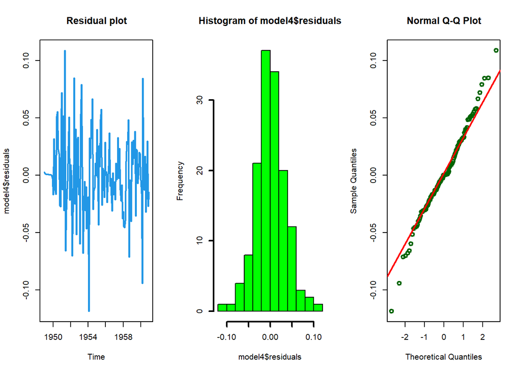

```r
par(mfrow=c(1,3))
plot(model4$residuals,col=4,lwd=2,main="Residual plot")
hist(model4$residuals, lwd=2,col="green")
qqnorm(residuals(model4), lwd=2,col="darkgreen")
qqline(residuals(model4), lwd=2,col="red")
```

From the Histogram and QQ plot we can say that residual is approximately normal

#### ACF and PACF of residual

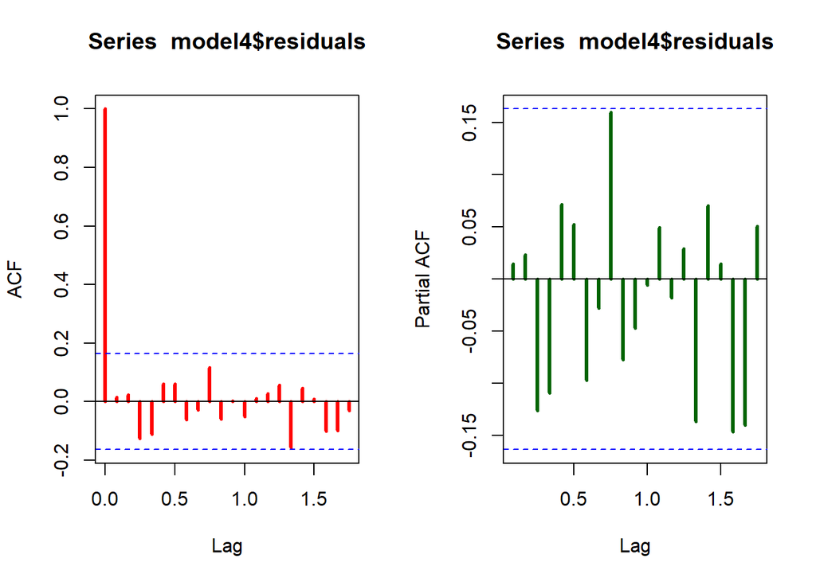

```r
par(mfrow=c(1,2))
acf(model4$residuals,lwd=3,col="red")
pacf(model4$residuals,lwd=3,col="darkgreen")
```

There is no significant spike of p and q. So, model of **residual is ARIMA(0,0,0)**

#### ADF test of residuals

```r
adf.test(model4$residuals,alternative ="stationary",12)
```

```
##
##  Augmented Dickey-Fuller Test
##
## data:  model4$residuals
## Dickey-Fuller = -3.2696, Lag order = 12, p-value = 0.07911
## alternative hypothesis: stationary
```

From Adf test, we are seeing residual is **stationary at 8% level of signicance.**

## auto.arima function for getting exact same arima model without manual selection and diagonistic

```r
library(forecast)
auto.arima(log(AirPassengers))
```

```
## Series: log(AirPassengers)
## ARIMA(0,1,1)(0,1,1)[12]
##
## Coefficients:
##           ma1     sma1
##       -0.4018  -0.5569
## s.e.   0.0896   0.0731
##
## sigma^2 = 0.001371:  log likelihood = 244.7
## AIC=-483.4   AICc=-483.21   BIC=-474.77
```

We are seeing it is giving same result as we got before

## Prediction

```r
prediction <- predict(model4,n.ahead=10*12) #10 years * 12 months
pred1<-round(2.718^prediction$pred,0)  # anti log and round to 0
pred1
```

```
##       Jan  Feb  Mar  Apr  May  Jun  Jul  Aug  Sep  Oct  Nov  Dec
## 1961  450  425  479  492  509  583  670  667  558  497  430  477
## 1962  496  468  527  542  560  642  737  734  614  547  473  525
## 1963  546  516  580  597  617  707  812  808  676  602  521  578
## 1964  601  568  639  657  679  778  894  890  745  663  573  637
## 1965  661  625  703  723  748  857  984  980  820  730  631  701
## 1966  728  688  775  796  823  943 1083 1079  903  804  695  772
## 1967  802  758  853  877  906 1039 1193 1188  994  885  765  850
## 1968  883  834  939  965  998 1143 1313 1308 1094  975  843  935
## 1969  972  919 1034 1063 1099 1259 1446 1440 1205 1073  928 1030
## 1970 1070 1012 1138 1170 1210 1386 1592 1585 1326 1181 1021 1134
```

### Plot the prediction

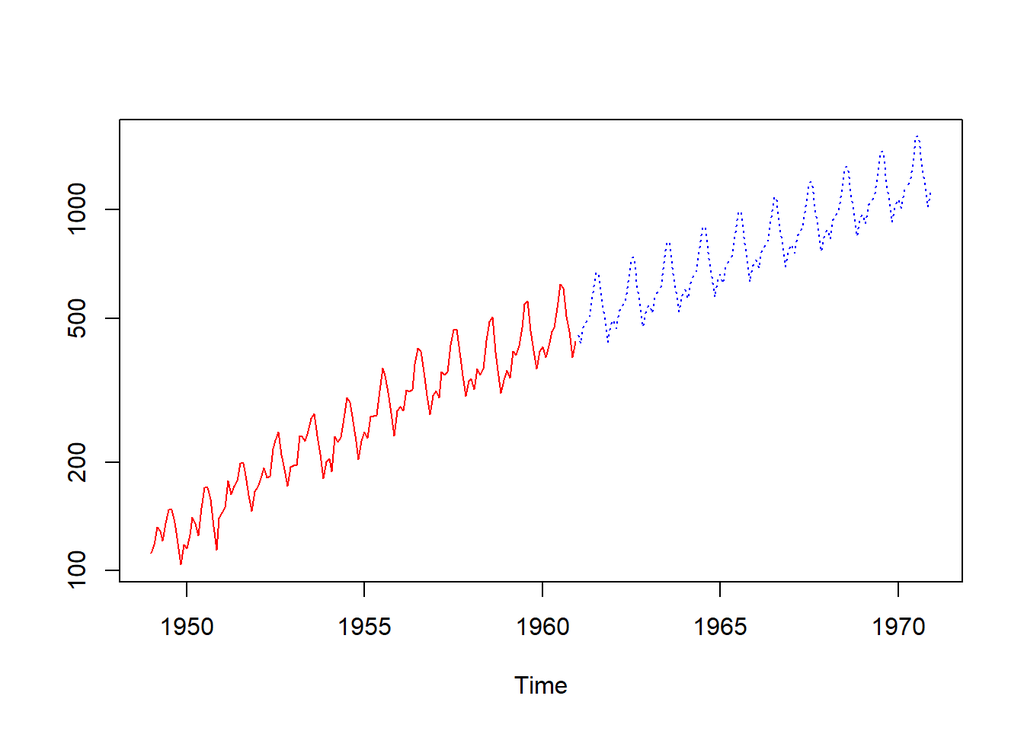

```r
ts.plot(AirPassengers,pred1,log="y",lty=c(1,3), col=c("red","blue"))
```

### Validation of the model

```r
Air49T59 = ts(AirPassengers, frequency = 12, start=c(1949,1), end=c(1959,12))
modelNew = arima(log(Air49T59),c(0,1,1),seasonal = list(order=c(0,1,1),period=12))

predNew = predict(modelNew,n.ahead=11*12)  # predict for now 1960 to 1970
pred2 = round(exp(1)^predNew$pred,0)

original_60=round(tail(AirPassengers,12),0) # Original 1960
predicted_60=round(head(pred2,12),0) # Predicted 1960
difference=original_60-predicted_60
rbind(original_60,predicted_60,difference)
```

```
##              [,1] [,2] [,3] [,4] [,5] [,6] [,7] [,8] [,9] [,10] [,11] [,12]
## original_60   417  391  419  461  472  535  622  606  508   461   390   432
## predicted_60  419  399  467  454  473  547  622  630  527   462   407   452
## difference     -2   -8  -48    7   -1  -12    0  -24  -19    -1   -17   -20
```

Difference is not so much compared to original data.

### Plotting the predicted model with original data

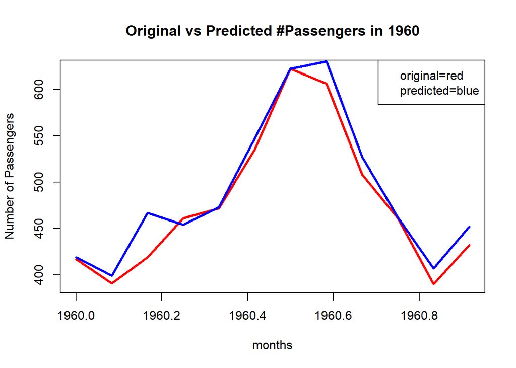

```r
plot(original_60,col="red", type="l",lwd=3,xlab="months",
     ylab="Number of Passengers",main="Original vs Predicted #Passengers in 1960")
lines(predicted_60,col="blue",lwd=3)
legend("topright",c("original=red","predicted=blue"))
```

Comment: Our predicted model performed well